# EDS 223: assignment 2

Colleen McCamy

2022-10-10

## introduction

The following exercises are modified from [Chapters 3](https://geocompr.robinlovelace.net/attr.html), [4](https://geocompr.robinlovelace.net/spatial-operations.html), [5](https://geocompr.robinlovelace.net/geometry-operations.html) of Geocomputation with R by Rovin Lovelace. Each question lists the total number of points. The breakdown of points can be found at the end of each instruction in parentheses. A general grading rubric can be found on the [course website](https://ryoliver.github.io/EDS_223_spatial_analysis/assignments.html).

Please update “author” to list your first and last names and any collaborators (e.g. Ruth Oliver, Friend1, Friend2).

**Due by midnight on Saturday 2022-10-22**

## prerequisites

```r
# add required packages here

library(sf)
library(spData)
library(tmap)
library(tidyverse)
library(rmapshaper)
library(rmapshaper)
library(smoothr)
```

## question 1

##### 5 points

Find the states that: (2.5)  
- belong to the West region  
- have an area below 250,000 square kilometers #### Units are needed!!  
- and greater than 5,000,000 residents in 2015

```r
#loading in the data and mutating AREA to numeric
us_data <- spData::us_states
class(us_data$AREA)
```

```
## [1] "units"
```

```r
us_data <- us_data |>
  mutate(AREA = as.numeric(AREA))

# filtering the us_data for the western regions
us_western <- us_data |>
  filter(REGION == "West")
#filtering the us_data for the area below 250,000
us_area250000_below <- us_data |>
  filter(AREA < 250000)
# filtering the states by population
us_pop_greater_5mil <- us_data |>
  filter(total_pop_15 > 5000000)

#combining the three filtering pieces
all_three_attributes <- us_data |>
  filter(REGION == "West") |>
  filter(AREA < 250000) |>
  filter(total_pop_15 > 5000000)

# ANSWER:
print(paste(all_three_attributes$NAME, "is in the Western region of the US, has an area below 250,000 km^2, and had a population greater than 5 million in 2015."))
```

```
## [1] "Washington is in the Western region of the US, has an area below 250,000 km^2, and had a population greater than 5 million in 2015."
```

What was the total population of the US in 2015? (2.5)

```r
#finding the sum
total_pop_2015 <- sum(us_data$total_pop_15)

#ANSWER:
print(paste0("The total population of the contiguous US in 2015 was ",total_pop_2015, " people."))
```

```
## [1] "The total population of the contiguous US in 2015 was 314375347 people."
```

## question 2

##### 5 points

Create a new variable named “us_states_stats” by adding variables from “us_states_df” to “us_states”. (3)

- Which function did you use and why? (0.5)
- Which variable is the key variable in both datasets? (0.5)
- What is the class of the new object? (0.5)
- Why does us_states_df have 2 more rows than us_states? (0.5)

```r
class(us_states)
```

```
## [1] "sf"         "data.frame"
```

```r
class(us_states_df)
```

```
## [1] "tbl_df"     "tbl"        "data.frame"
```

```r
# edited the column name for states
us_states_df <- us_states_df |>
  mutate(NAME = state)
#merged the data
us_states_stats <- merge(us_states, us_states_df, by = "NAME")

#ANSWER:
print(paste("I used the merge() function as the class for us_states is an sf object and data.frame and the us_states_df class is a data.frame. I noticed that using merge excluded Alaska and Hawaii from the new object as they didn't have spatial geometries associated with them. If I wanted to keep the data for Alaska and Hawaii, I could have used a left join."))
```

[output not shown]

```r
#ANSWER:
print(paste("The state name is the key variable between both datasets."))
```

```
## [1] "The state name is the key variable between both datasets."
```

```r
class(us_states_stats)
```

```
## [1] "sf"         "data.frame"
```

```r
#ANSWER:
print(paste("The class of the new object us_states_stats is an sf object and data.frame."))
```

```
## [1] "The class of the new object us_states_stats is an sf object and data.frame."
```

```r
#ANSWER:
print(paste("The us_states_df included data for 'Alaska' and 'Hawaii' while the the 'us_states'only included in the contiguous United States. Thus, in merging the data with the code below, the data for Alaska and Hawaii in the 'us_states_df' was omitted."))
```

```
## [1] "The us_states_df included data for 'Alaska' and 'Hawaii' while the the 'us_states'only included in the contiguous United States. Thus, in merging the data with the code below, the data for Alaska and Hawaii in the 'us_states_df' was omitted."
```

## question 3

##### 10 points

Make a map of the percent change in population density between 2010 and 2015 in each state. Map should include a legend that is easily readable. (7)

```
## Variable(s) "pop_den_diff" contains positive and negative values, so midpoint is set to 0. Set midpoint = NA to show the full spectrum of the color palette.
```

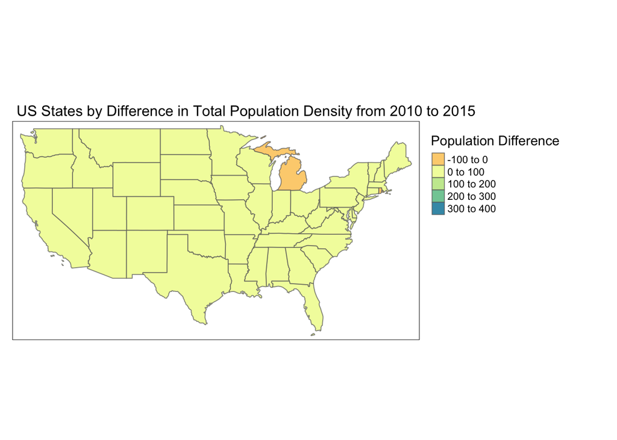

```r
#adding population density difference in the dataframe to map
us_states_map <- us_states_stats |>
  mutate(AREA = as.numeric(AREA)) |>
  mutate(pop_den_15 = total_pop_15/AREA) |>
  mutate(pop_den_10 = total_pop_10/AREA) |>
  mutate(pop_den_diff = pop_den_15 - pop_den_10)

#mapping the results
tm_shape(us_states_map) +
  tm_fill(col = "pop_den_diff",
          title = "Population Difference",
          palette = "Spectral") +
  tm_layout(legend.outside = TRUE,
            main.title = "US States by Difference in Total Population Density from 2010 to 2015",
            main.title.size = 1) +
  tm_borders(alpha = 0.7)
```

In how many states did population density decrease? (3)

```r
#filtering for population difference less than 0
pop_decrease <- us_states_map |>
  filter(pop_den_diff < 0)
#seeing how many rows are in the dataframe which will tell us how many states saw a decrease in population
nrow(pop_decrease)
```

```
## [1] 2
```

```r
#ANSWER:
print(paste(nrow(pop_decrease), "states, Michigan and Rhode Island, had a decrease in population from 2010 to 2015."))
```

```
## [1] "2 states, Michigan and Rhode Island, had a decrease in population from 2010 to 2015."
```

## question 4

##### 10 points

How many of New Zealand’s high points are in the Canterbury region? (5)

```r
#storing the data in the environment
nz <- nz
nz_height <- nz_height

# creating an object for Canterbury data
canterbury <- nz |>
  filter(Name == "Canterbury")

#figuring out all of the points inside canterbury similar to select
canterbury_heights <- nz_height[canterbury,]

#determining the number of points
nrow(canterbury_heights)
```

```
## [1] 70
```

```r
#ANSWER:
print(paste(nrow(canterbury_heights), "of New Zealand's highest points are in the Canterbury region."))
```

```
## [1] "70 of New Zealand's highest points are in the Canterbury region."
```

Which region has the second highest number of “nz_height” points? And how many does it have? (5)

```r
#combining the data for nz_height and nz ojects
region_height <- st_join(nz_height, nz)

# ordering the data based on regions which have heights
region_height_order <- region_height |>
  count(Name, sort = TRUE)

#ANSWER:
print(paste("The second highest number of 'nz_height' points is the", region_height_order$Name[2], "with", region_height_order$n[2], "points within the nz_height data."))
```

```
## [1] "The second highest number of 'nz_height' points is the West Coast with 22 points within the nz_height data."
```

## question 5

##### 15 points

Create a new object representing all of the states the geographically intersect with Colorado.(5)  
Hint: use the “united_states” dataset. The most concise way to do this is with the subsetting method “[”.  
Make a map of the resulting states. (2.5)

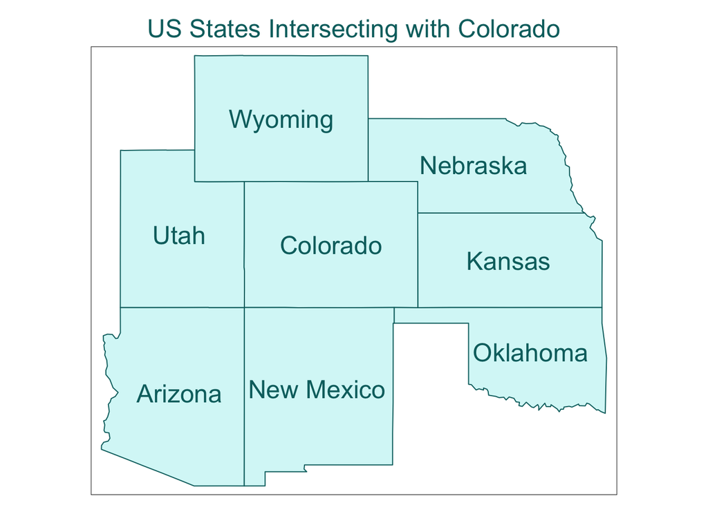

```r
us_states <- us_states

# creating object of Colorado
co <- us_states |>
  filter(NAME == "Colorado")

# creating a TRUE/FALSE list of states that intersect with Colorado
co_intersect <- st_intersects(x = us_states, y = co)
co_logical <- lengths(co_intersect) > 0

# filtering the list based on the logical TRUE/FALSE statement
co_intersect_true <- us_states[co_logical, ]

# mapping the data
tm_shape(co_intersect_true) +
  tm_polygons(col = "#d7f7f7",
              border.col = "#056e6e") +
  tm_layout(main.title = "US States Intersecting with Colorado",
            main.title.color = "#056e6e",
            main.title.position = "center") +
  tm_text("NAME",
          col = "#056e6e",
          size = 1.5)
```

Create another object representing all the objects that touch (have a shared boundary with) Colorado and plot the result.(5)  
Hint: remember you can use the argument op = st_intersects and other spatial relations during spatial subsetting operations in base R).  
Make a map of the resulting states. (2.5)

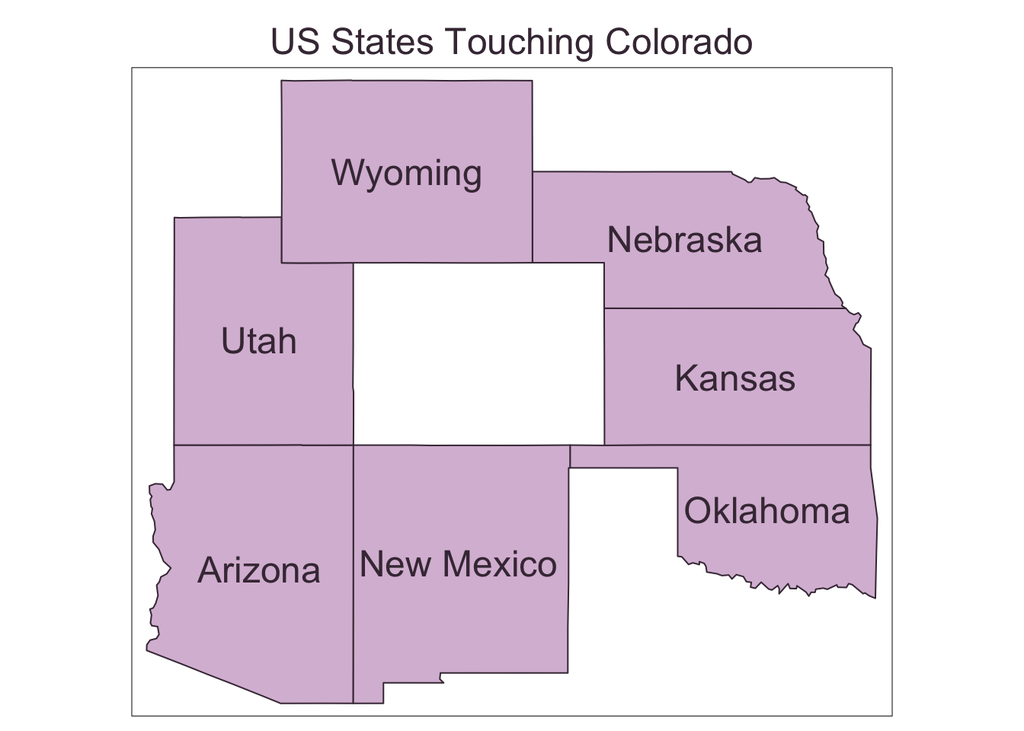

```r
# creating a TRUE/FALSE list of states that touch Colorado
co_touch <- st_touches(x = us_states, y = co)
co_logical_touch <- lengths(co_touch) > 0

# filtering the list based on the logical TRUE/FALSE statement
co_touch_true <- us_states[co_logical_touch, ]

# mapping the data
tm_shape(co_touch_true) +
  tm_polygons(col = "#d9bdd7",
              border.col = "#453444") +
  tm_layout(main.title = "US States Touching Colorado",
            main.title.color = "#453444",
            main.title.position = "center") +
  tm_text("NAME",
          col = "#453444",
          size = 1.5)
```

## question 6

##### 10 points

Generate simplified versions of the “nz” dataset. Experiment with different values of keep (ranging from 0.5 to 0.00005) for **ms_simplify()** and dTolerance (from 100 to 100,000) **st_simplify()**. (5)

Map the results to show how the simplification changes as you change values.(5)

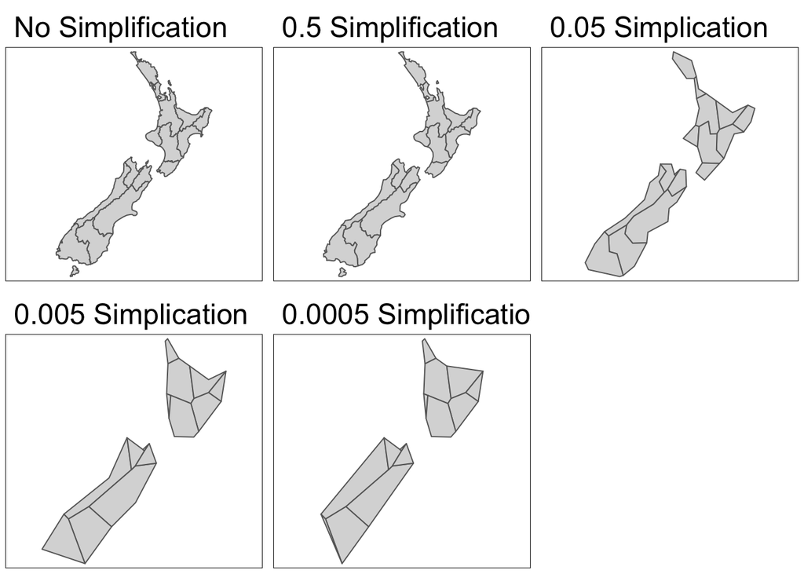

```r
# ----- using ms_simplify()
nz_ms_0.5 <- ms_simplify(nz, 0.5)
nz_ms_0.0005 <- ms_simplify(nz, 0.0005)
nz_ms_0.005 <- ms_simplify(nz, 0.005)
nz_ms_0.05 <- ms_simplify(nz, 0.05)

#creating maps
ms_0 <-tm_shape(nz) +
  tm_polygons() +
  tm_layout(main.title = "No Simplification")
ms_1 <- tm_shape(nz_ms_0.5) +
  tm_polygons() +
    tm_layout(main.title = "0.5 Simplification")
ms_2 <- tm_shape(nz_ms_0.005) +
  tm_polygons() +
  tm_layout(main.title = "0.005 Simplication")
ms_3 <- tm_shape(nz_ms_0.0005) +
  tm_polygons() +
  tm_layout(main.title = "0.0005 Simplification")
ms_4 <- tm_shape(nz_ms_0.05) +
  tm_polygons() +
  tm_layout(main.title = "0.05 Simplication")

# joining the maps into one figure
ms_map_comparison <- tmap_arrange(ms_0, ms_1, ms_4, ms_2, ms_3)
ms_map_comparison
```

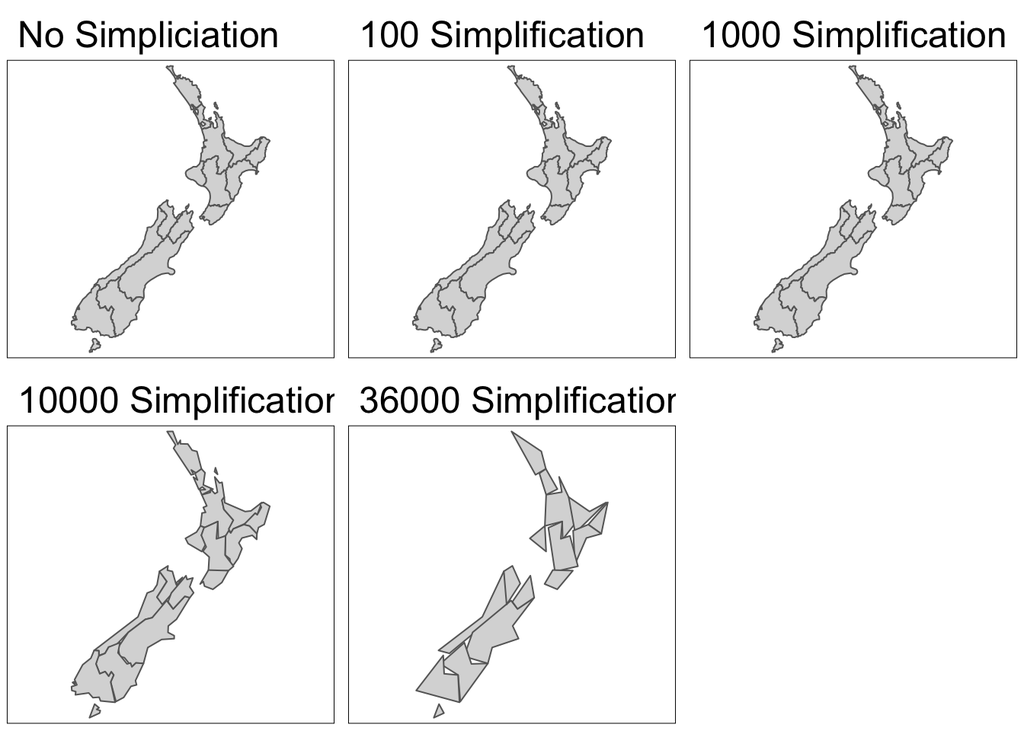

```r
# ----- using st_simplify()
nz_st_100 <- st_simplify(nz, preserveTopology = FALSE, dTolerance = 100)
nz_st_1000 <- st_simplify(nz, preserveTopology = FALSE, dTolerance = 1000)
nz_st_10000 <- st_simplify(nz, preserveTopology = FALSE, dTolerance = 10000)
nz_st_36000<- st_simplify(nz, preserveTopology = FALSE, dTolerance = 36000)

#creating the maps with the simplifications above
st_0 <- tm_shape(nz) +
  tm_polygons() +
  tm_layout(main.title = "No Simpliciation")
st_1 <- tm_shape(nz_st_100) +
  tm_polygons() +
    tm_layout(main.title = "100 Simplification")
st_2 <- tm_shape(nz_st_1000) +
  tm_polygons() +
    tm_layout(main.title = "1000 Simplification")
st_3 <- tm_shape(nz_st_10000) +
  tm_polygons() +
    tm_layout(main.title = "10000 Simplification")
st_4 <- tm_shape(nz_st_36000) +
  tm_polygons() +
    tm_layout(main.title = "36000 Simplification")

#combining all the maps in one figure
st_map_comparison_2 <- tmap_arrange(st_0, st_1, st_2, st_3, st_4)
st_map_comparison_2
```